# R Training 2

# Introduction

Welcome back! In this tutorial we will learn how to apply filters to our signals, as wells as learn how to sort though data.

# Exercise 5: Filter a signal

First let’s filter an artificial signal. We’ll add two sinewaves together:

one with a frequency of 5 kHz and the other at 500 Hz. We’ve done this before, so no problem!

```r
freq1 = 5000;
freq2 = 500;

sampleFs = 20000;
intvl = 1/sampleFs;
secs = 2;
tim = seq(intvl, secs, intvl)
amp1 = 1;
amp2 = 1;
wave1 = sin(tim*2*pi*freq1) * amp1;
wave2 = sin(tim*2*pi*freq2) * amp2;
addwav = wave1 + wave2;
```

We’ll do a high-pass and a low-pass filter. We can have different frequencies for the high- and low-pass parts, but to start we’ll use the same frequency, 2500Hz.

```r
lowcut = 2500
highcut = 2500
```

These next steps make the filter. There are many types of filter – the one we are using is called a “Butterworth” filter. The only thing to change here is the order, **n** – which is the slope of the filter. Lower numbers have a broader slope, whereas higher numbers have a steeper slope.

### Syntax

We will be using the function:

bwfilter(wave, f, n = 1, from = NULL, to = NULL, bandpass = TRUE)

We can specify a few parameters: **wave** specifies our wave file, **f** is the sampling frequency, **n** is the order of the filter, **from** and**to** give the start and end frequencies, respectively. Don’t worry about **bandpass** right now.

```r
lowfilt = bwfilter(addwav, sampleFs, n = 5, from = NULL, to = 2500 )
highfilt = bwfilter(addwav, sampleFs, n = 5, from = 2500, to = NULL )
```

Now let’s plot the results.

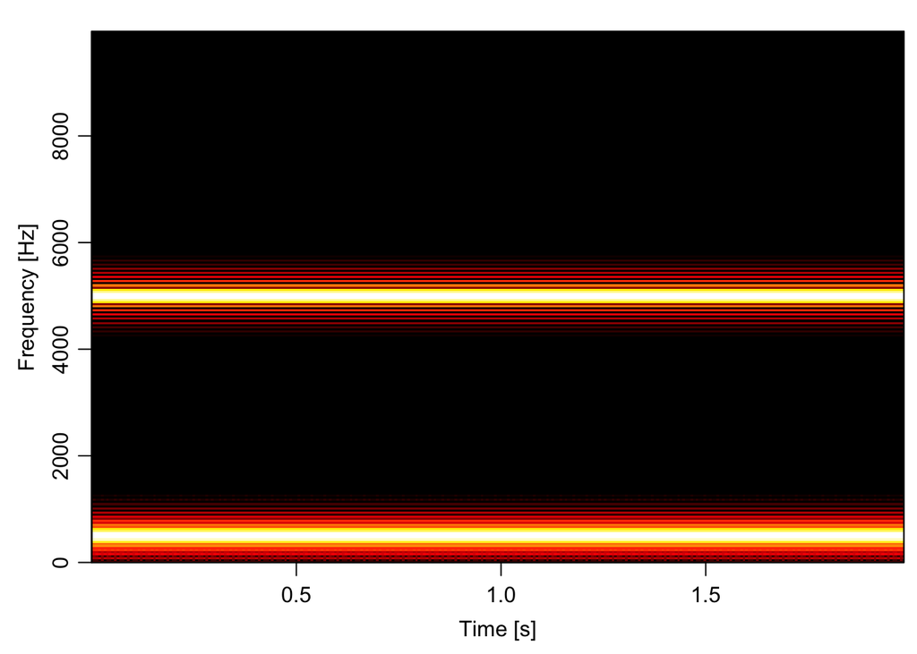

```r
specplot(addwav, Fs = sampleFs)
```

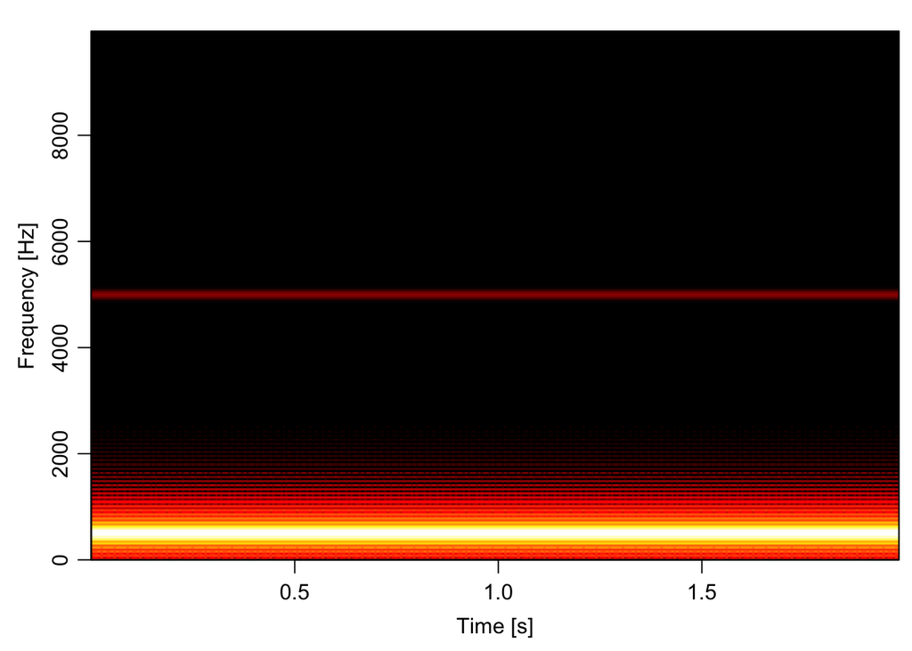

```r
specplot(lowfilt, Fs = sampleFs)
```

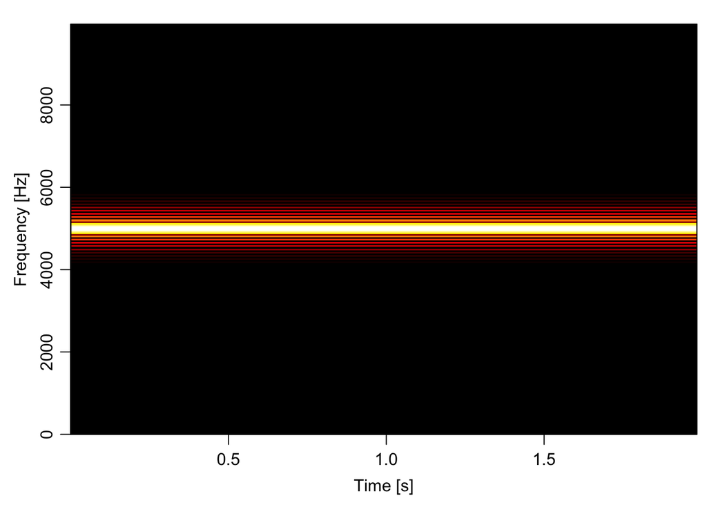

```r
specplot(highfilt, Fs = sampleFs)
```

# Exercise 6: Filter a signal - noise

The first step is to make a noisy signal. Set the length, in seconds

```r
len = 1
```

Set the SampleRate, in Hz. and make a time series…

```r
sampleFs = 20000
```

Make the noise sequence using **runif**. This function generates a series of random numbers within a set min and max value.

### Syntax

runif(number_of_numbers, min, max). If you want a random sequence taken from a normal distribution you can use rnorm.

```r
noisy = runif(length(tim), min = -2^16, max = 2^16)
```

This is great - we can plot this

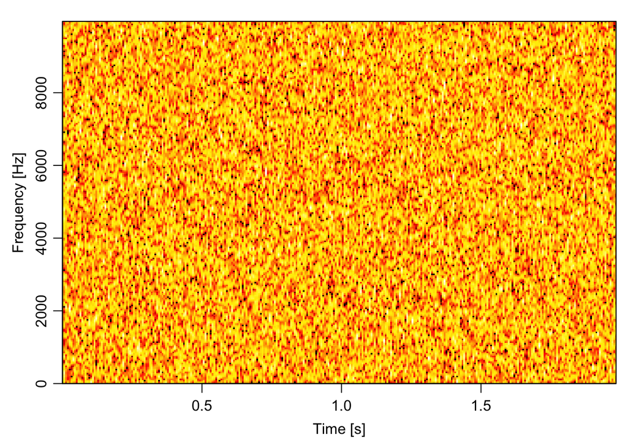

```r
specplot(noisy, Fs = sampleFs)
```

Now we filter, as above, this time using differnt frequencies for our filters.

Our low pass filter will have a max frequency of 1500. Our high pass filter will have a minimum frequency of 2700.

```r
lowfilt_noise = bwfilter(noisy, sampleFs, n = 5, from = NULL, to = 1500 )
highfilt_noise = bwfilter(noisy, sampleFs, n = 5, from = 2700, to = NULL )
```

Now we can plot these as sonograms.

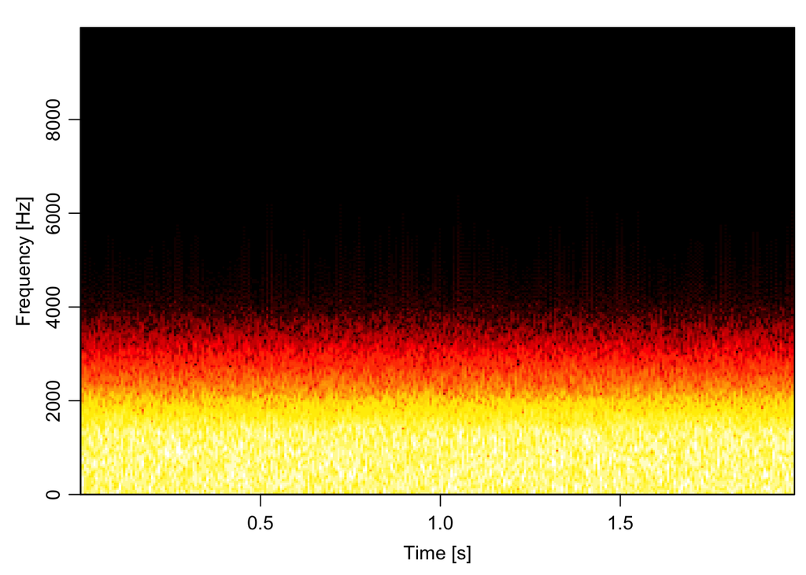

```r
specplot(lowfilt_noise, Fs = sampleFs)
```

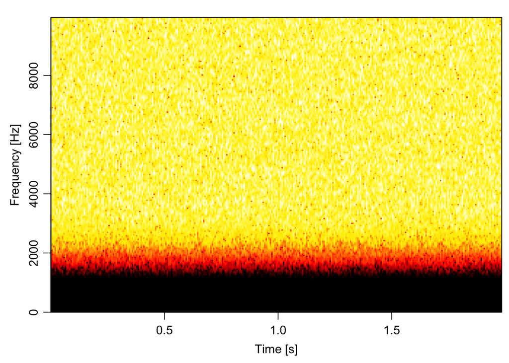

```r
specplot(highfilt_noise, Fs = sampleFs)
```

### Exercise 6.1

Vary the ‘order’ of the filter between 1 and 9. What happens?

Can you make a bandpass signal, where you filter out signal below 1000 Hz and above 7700 Hz??